# ass2

## Q1.

```python
import numpy as np
import matplotlib.pyplot as plt
latency=np.array([5e-6,6e-6])
bandwitdth=np.array([100,125])
def communication_time(size,device):
    return latency[device]+size/bandwitdth[device]
```

```python
t1=communication_time(128*8*10e-9,0)
t2=communication_time(128*8*10e-9,1)
print("The time needed to transfer 128 Bytes for device A is ",t1 ,"sec")
print("The time needed to transfer 128 Bytes for device B is ",t2 ,"sec")
print("Ratio=",t2/t1)
```

```
The time needed to transfer 128 Bytes for device A is  5.1024000000000005e-06 sec
The time needed to transfer 128 Bytes for device B is  6.08192e-06 sec
Ratio= 1.1919724051426779
```

For a message size of 128 Bytes, device A performs better dellivering 1.2X faster communication time than device B.

This is not sufficient to make a decision since the KAUST supercomputer will receive messages of different sizes so the study should be performed on various sizes to check which configuration serves us better.

For that reason we measured the throughput of a system for messages with different sizes that ranges from 128 Bytes to around 67MBytes

```python
times=np.zeros((2,20))
s=64
l_s=[]
for i in range (20) :
    s=s*2
    times[0,i]=communication_time(s*8*10e-9,0)
    times[1,i]=communication_time(s*8*10e-9,1)
    l_s.append(s)
```

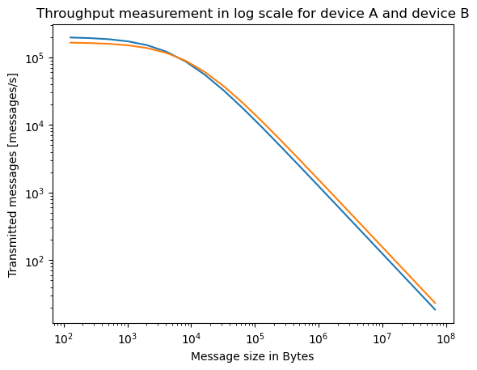

```python
plt.loglog(l_s,1/times[0])
plt.loglog(l_s,1/times[1])
plt.ylabel("Transmitted messages [messages/s]")
plt.xlabel("Message size in Bytes")
plt.title('Throughput measurement in log scale for device A and device B')
plt.show()
```

As we can see in the above graph, we devide each device results into two :

- Latency bound communication: This is when the message size is small, the communication throughout will be limited by the latency of the interconnect. In this case device A performs better.
- Bandwidth bound communication: This is when the message size is big, the communication throughout will be limited by the bandwidth of the interconnect. In this case device B performs better.

The two lines meets in one point with a size $S^*=\frac{\alpha _2- \alpha _1}{\beta _1 - \beta _2}$ where $\alpha$ is the latency and $\beta$ is the inverse of the bandwidth.

Depending on the size of the workload that KAUST interconnect will manage the decision is made .If most of the transferred messages are less than the decision threshhold $S^*$ then device A will serves us better otherwise we choose device B.